# Coursework Report

*N* removed NAs: 7

*N* removed <18: 29

**Correct typo age:** 24

*N* total clean: 132

| Group | *N* | *M*<sub>age</sub> | % green |
| --- | --- | --- | --- |
| Control | 65 | 21.05 | 34.36 |
| Experim | 67 | 20.60 | 52.74 |

| Gender | *N* | *M*<sub>age</sub> | % green |
| --- | --- | --- | --- |
| Male | 70 | 20.76 | 42.86 |
| Female | 39 | 21.00 | 46.15 |
| Other | 23 | 20.70 | 42.03 |

**Main analysis results**

**car:**  
χ<sup>2</sup>(1) = 1.2, *p* = .274

**cleaner:**  
χ<sup>2</sup>(1) = 1.55, *p* = .213

**dishwasher:**  
χ<sup>2</sup>(1) = 12.34, *p* < .001

[interactive chart not shown]

[figure not shown]

[interactive chart not shown]

# Coursework Report

Analysing Data, Spring 2020

This student has a record of specific learning difficulty (dyslexia/dyspraxia). Please mark this report in accordance with the [marking guidelines for SLD](https://www.sussex.ac.uk/studentsupport/staff/spld?fbclid=IwAR2lYKD6xvuv9egQDvG8d_oed9GUD3KXQn3gAdlHZ1gQB8gDddBdeOEmKdE).

# Methods

## Participants

Table 1 *Descriptive statistics by Gender*

[output not shown]

Table 2 Summary of Participant Demographics by Experimental Condition

[output not shown]

## Design

It is suggested by (Griskevicius, Tybur, & Van, 2010) the reason why consumers are motivated to buy green products with less beneficial personal uses is because the green product presents the owner as having high status and altruistic qualities.

To investigate this, this study carried out a replication of (Griskevicius, et al, 2010) study. This consisted of two between subject conditions, an experimental condition where status motive was activated and control condition where status motive was not activated. Status motive was activated by participants reading a short story which has suggested to activate status motive (Griskevicius, Goldstein, Mortensen, et al, 2009) and the control read a similar story with no link to status motives. To avoid demand characteristics participants were deceived and told they were taking part in several studies and the first would test memory. Participants were then asked a scenario-based question ‘“If you were out shopping for a car/dishwasher/household cleaner, which of these two products would you buy?”. The three products were classed as luxury products by luxury and performance qualities, and green products by superior environmental qualities. Although the green and luxury counterpart were the same price, same company manufacturer and the same three descriptive qualities of the products.

To confirm the activation of status motive meant the participants choice of product was influenced by their desire to be viewed by others as having greater status. In connection to status motive Griskevicius, et al (2010) carried out a pre-test to suggest the green products were viewed as being more prosocial to the luxury products. Therefore, allowing the prediction that status motives should lead people to want to be viewed more prosocial to be addressed. In consideration, if a participant wanted to be viewed more altruistic, they would be likely to select the green product as opposed to the non-green product.

The age and gender of participants was also obtained prior to the study. Gender was classified as female, male and other. It is important to elucidate for sake of analysis that variable’s including participant condition, product type, product category and gender were factor variables as age was a numerical variable.

This study argues that participants who were in the experimental condition where status motive was activated would be more likely to select the green products as opposed to the non-green products as the control condition where status motive was not activated would not see a difference in product choice.

# Results

It was expected that the control condition where status motive was not activated would select the more luxury alternative compared to the green product. As predicted, in the control condition participants had an increased likelihood to choose the non-green Dishwasher (70.31% chose the non green Dishwasher), the non green Cleaner (61.54% chose the non green Cleaner) and non green Car (64.62% chose the non green car). This show’s that when participants status motive had not been activated, the three more luxurious non green products were more attractive than the green alternatives.

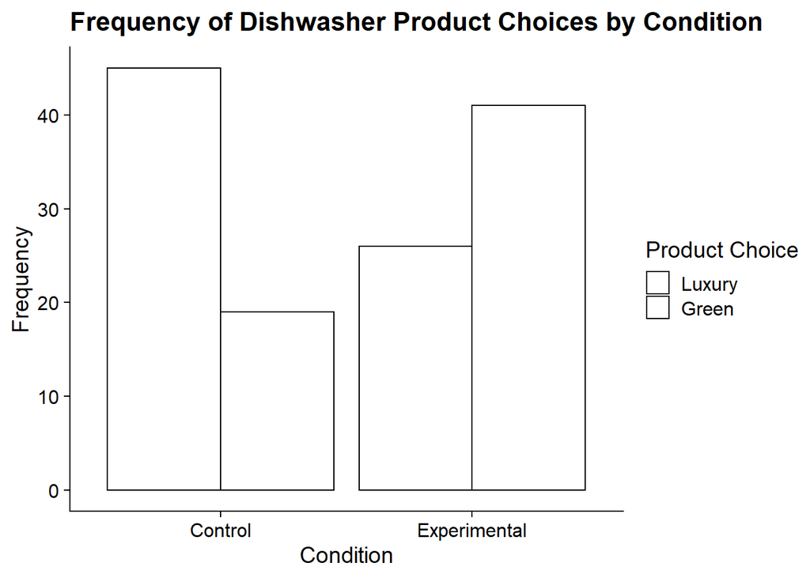

Secondly, in relationship to Cars we found that 46.27% of participants who read the high status story chose a green Car over the non green Car, while 35.38% participants in the control chose the green Car *χ*<sup>2</sup>(1) = 1.2, *p* = 0.274. The p value at 0.274 suggests it is unlikely that there is an assocaition and rather it is unlikely there is an association between activating status motives and people choosing a green Car. This is visible in Figure 2.

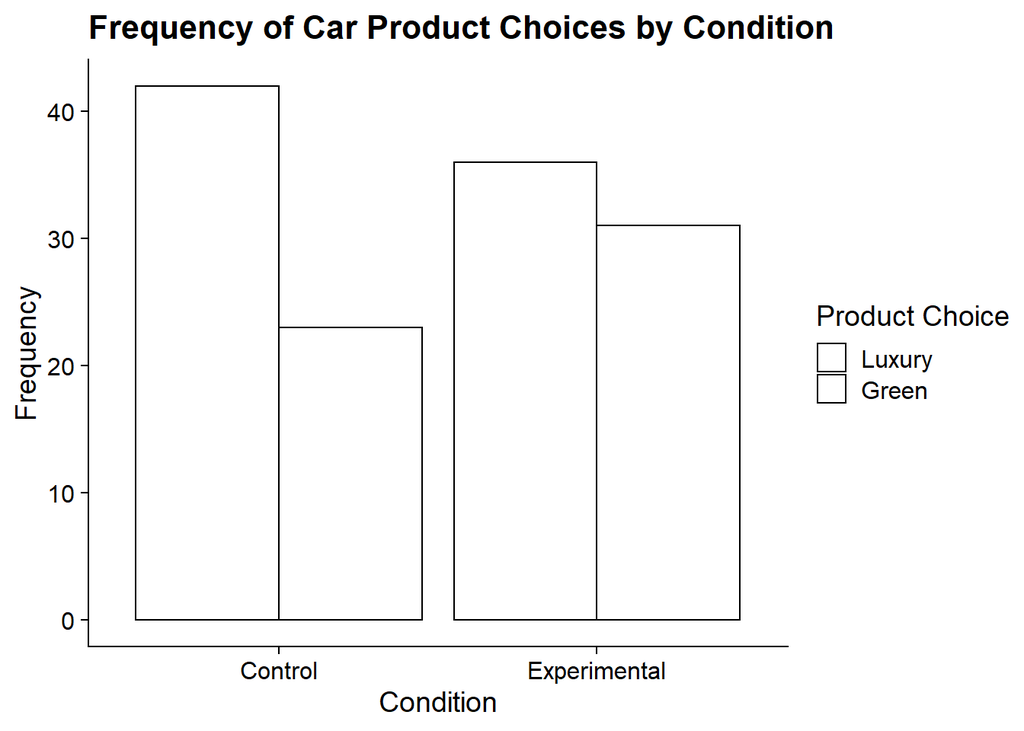

Similarly, when considering the Cleaner, the results found that 50.75% of participants in the high status experimental condition selected the green Cleaner as opposed to the non green Cleaner, as 38.46% of the control chose the green Cleaner *χ*<sup>2</sup>(1) = 1.55, *p* = 0.213. The p value at 0.213 implies it is likely that there is no assocaition and rather it is unlikely there is an association between activating status motives and people choosing a green Cleaner. This relationship is visible in Figure 3.

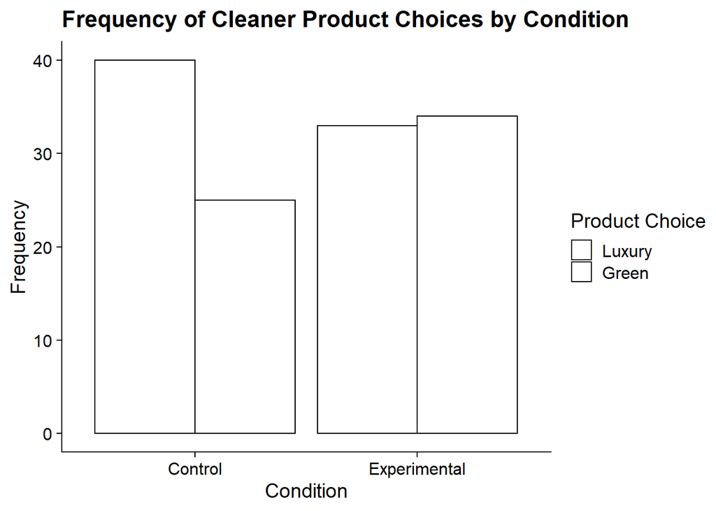

***

# Discussion

Reasons for why people buy pro environmental products as opposed to more luxury non green products is broad. For instance, Hartmann and Apaolaza-Ibáñez (2012) study suggests a person may buy a green product as opposed to a non-green product as a result of powerful branding in which natural imagery provokes a green option rather than the motives of self-expressive benefits. However, as branding in this case was indifferent, this does not provide a plausible alternative.

Anderson, Hildreth and Howland’s (2015) review reinforces the idea that an individual’s desire to gain status has central importance to people. The review suggests status effects a person’s well-being, self-esteem, and mental and physical health. Therefore, presenting how powerful the desire for status may have to shape a person’s choices. This is visible in a study which also (Sundie, Kenrick, Griskevicius, et al 2011) suggests people use product choice as a status signal, in order to gain desires. Sundie’s study found that flaunting status-linked products to a possible partner allowed a male to present their economic resources and find a short-term partner. This seems to show that activating status motives alters a person’s product choice, but it is dependent on the context and attitude what product choice is viewed as gaining status. As in this study pro environmental products are associated with increasing status as in contrast in Sundie’s study more economically priced and luxury product were viewed as increasing status.

Individual differences are therefore important to consider when interpretating this study. As although the study activated status motive and it seemed higher status could be gained by selecting the green product. It may be dependent on the social group whether they view the green product as increasing status. It may be that this choice allows status gains relevant to prestige but other status gains such as male dominance may not be gained through picking a green product but rather through physical dominance (Mazur, & Booth, 1998). Therefore, perhaps future research could do replications of this study with different sample groups, to investigate whether it may be a person’s perception on what gains them status to influence their product choice. A persons attitude on what gains them status could be added to the study to explore this connection perhaps using The MacArthur scale of subjective social status (Adler & Stewart, 2007), or maybe a more specific questionnaire.

It also important to consider that the validly of the study’s story activating status motive may be questionable. Although there is evidence to support activating status leads to a pro environmental option such as a study (Puska, Kurki, Lähdesmäki, Siltaoja, & Luomala, 2018) that found activating status motive through memorising a list of words with nouns related to status in the list, (Maio, Pakizeh, Cheung, & Rees, 2009) led to an increase in people buying organic food products as opposed to the non-organic food counterpart. However, apart from this study there seems to be little research which investigates the relationship between activation of status motive and buying pro environmental products which does not use Grivkesvicius (2009) story to activate status motive (Talukdar, 2020). Perhaps future research could replicate this study but by using other ways of activating status motive other than through a story (Griskevicius, Goldstein, Mortensen, et al, 2009).

The results of this can also help explain a relatively novel framework on how to encourage pro environmental behavior (Steg, Bolderdijk, Keizer, Perlaviciute, 2014). This framework develops from a Goal framing theory (Lindenberg & Steg,2007), that suggests that acting in an environmentally friendly way causes conflict in a person’s goal, where hedonic goals, normative goals and gain goals compete and in order to make a person behave in a pro environmental manner you have to reduce the conflict between these goals. For instance, in relevance to this study activating status motive may make a person focus on gains goals of increasing status, therefore reducing the conflict of goals as they are focused on gain goals. In this case selecting the green product in the experimental condition allowed them to achieve the gain goal of increasing status, as the green product seemed to be associated more with status than the non-green product. The study seems to support one of the frameworks main assumption that changing a person’s perception on the outcome of behaving environmentally will alter their choice. However, future research may want to investigate the frameworks idea that reinforcing normative goals connected to the environment will reduce conflict between goals by making normative goals of higher priority, suggesting people will behave in a pro environmental way by responding in a normative way.

In conclusion, it is suggested that people may behave in an altruistic manner as their main intention is to maintain their reputation. This study reflects people selecting a pro environmental and pro social option due to its associated status gains, when a person status motive is activated. Future research could explore this association between status and purchasing pro green products by investigating whether what a person perceives as giving them social status influences their choices.

# References

Adler, N., & Stewart, J. (2007). The MacArthur scale of subjective social status. MacArthur Research Network on SES & Health. Retrieved from http://www. macses. ucsf. edu/Research/Psychosocial/subjective. php. DOI: https://scholar.google.co.uk/citations?user=ogKs6mIAAAAJ&hl=en&oi=sra

Anderson, C., Hildreth, J. A. D., & Howland, L. (2015). Is the desire for status a fundamental human motive? A review of the empirical literature. Psychological Bulletin, 141(3), 574. DOI: https://pdfs.semanticscholar.org/48cd/8f785a2ea53b3e537dbc7268cbfbe62b6042.pdf

Griskevicius, V., Tybur, J. M., & Van den Bergh, B. (2010). Going green to be seen: status, reputation, and conspicuous conservation. *Journal of personality and social psychology*|, 98(3), 392. DOI: file:///C:/Users/Eloise/Desktop/Analysing%20data/Report/green%20study%20paper.pdf

Hartmann, P., & Apaolaza-Ibáñez, V. (2012). Consumer attitude and purchase intention toward green energy brands: The roles of psychological benefits and environmental concern. *Journal of business Research*, 65(9), 1254-1263. DOI: https://www.sciencedirect.com/science/article/pii/S0148296311004012?casa_token=wHtFJBs2rU4AAAAA:eX3C5BXLAzulBI745YofOgI5CS6fG1v6vkXUCOd0sgRm_xCnKkz2q-5aTqf4IBeFDWQDZV5FoMM

Lindenberg, S., & Steg, L. (2007).

Normative, gain and hedonic goal frames guiding environmental behavior. *Journal of Social issues*, 63(1), 117-137. DOI: https://spssi.onlinelibrary.wiley.com/doi/full/10.1111/j.1540-4560.2007.00499.x?casa_token=jIfY4oAsq9MAAAAA:nFHtuzSOcOzcan8QvcwYpg05IKxhgjs7VnS0V7OkS91UdJTBg8aat8z1icIrylfbjLZOlQnLVPP8Mow

Maio, G. R., Pakizeh, A., Cheung, W. Y., & Rees, K. J. (2009). Changing, priming, and acting on values: effects via motivational relations in a circular model. *Journal of personality and social psychology*, 97(4), 699. DOI: https://eprints.soton.ac.uk/169457/1/Values_priming_JPSP.pdf

Mazur, A., & Booth, A. (1998). Testosterone and dominance in men. Behavioral and brain sciences, 21(3), 353-363. DOI: http://cogprints.org/663/1/bbs_mazur.html

Puska, P., Kurki, S., Lähdesmäki, M., Siltaoja, M., & Luomala, H. (2018). Sweet taste of prosocial status signaling: When eating organic foods makes you happy and hopeful. Appetite, 121, 348-359. DOI: https://osuva.uwasa.fi/bitstream/handle/10024/8212/Osuva_Puska_Kurki_L%C3%A4hdesm%C3%A4ki_Siltaoja_Luomala_2018.pdf?sequence=2&isAllowed=y

Steg, L., Bolderdijk, J. W., Keizer, K., & Perlaviciute, G. (2014). An integrated framework for encouraging pro-environmental behaviour: The role of values, situational factors and goals. *Journal of Environmental psychology*, 38, 104-115. DOI: https://www.sciencedirect.com/science/article/pii/S027249441400005X

Sundie, J. M., Kenrick, D. T., Griskevicius, V., Tybur, J. M., Vohs, K. D., & Beal, D. J. (2011). Peacocks, Porsches, and Thorstein Veblen: Conspicuous consumption as a sexual signaling system. *Journal of personality and social psychology*, 100(4), 664. DOI: https://pdfs.semanticscholar.org/b944/dad3b7501b97c9f181eb35aca4df32cb30b7.pdf

Talukdar, N., & Yu, S. (2020). Do materialists care about sustainable luxury?. Marketing Intelligence & Planning. DOI: https://www.researchgate.net/profile/Nabanita_Talukdar3/publication/339322231_Do_materialists_care_about_sustainable_luxury/links/5e53ed21299bf18082de69d7/Do-materialists-care-about-sustainable-luxury.pdf#page=1&zoom=auto,-149,686